# Projeto - IoT

Exercício baseado no problema publicado no Kaggle: https://www.kaggle.com/arnabbiswas1/microsoft-azure-predictive-maintenance?select=PdM_telemetry.csv

**Contexto:** This an example data source which can be used for Predictive Maintenance Model Building. It consists of the following data:

- Machine conditions and usage: The operating conditions of a machine e.g. data collected from sensors.
- Failure history: The failure history of a machine or component within the machine.
- Maintenance history: The repair history of a machine, e.g. error codes, previous maintenance activities or component replacements.
- Machine features: The features of a machine, e.g. engine size, make and model, location.

Contato pelo Linkedin: https://bit.ly/3tsOnU3

# 1. Obtém o dataset através da API do Kaggle

```
Arquivos já existentes!
Arquivos carregados.
```

```
Tamanho dos datasets:
	- Errors    : (3919, 3)
	- Failures  : (761, 3)
	- Machines  : (100, 3)
	- Maint     : (3286, 3)
	- Telemetry : (876100, 6)
```

**Tabela 1 - Histórico de log de erros - 5 primeiros elementos**

|  | datetime | machineID | errorID |
| --- | --- | --- | --- |
| 0 | 2015-01-03 07:00:00 | 1 | error1 |
| 1 | 2015-01-03 20:00:00 | 1 | error3 |
| 2 | 2015-01-04 06:00:00 | 1 | error5 |
| 3 | 2015-01-10 15:00:00 | 1 | error4 |
| 4 | 2015-01-22 10:00:00 | 1 | error4 |

```
Data do dado mais antigo de log de erro: 2015-01-01 06:00:00
Data do dado mais novo de log de erro: 2016-01-01 05:00:00
```

**Tabela 2 - Histórico de substituição de componentes devido a falhas - 5 primeiros elementos**

|  | datetime | machineID | failure |
| --- | --- | --- | --- |
| 0 | 2015-01-05 06:00:00 | 1 | comp4 |
| 1 | 2015-03-06 06:00:00 | 1 | comp1 |
| 2 | 2015-04-20 06:00:00 | 1 | comp2 |
| 3 | 2015-06-19 06:00:00 | 1 | comp4 |
| 4 | 2015-09-02 06:00:00 | 1 | comp4 |

```
Data do dado mais antigo de substituição de componente: 2015-01-02 03:00:00
Data do dado mais novo de substituição de componente: 2015-12-31 06:00:00
```

**Tabela 3 - Inventário de máquinas - 5 primeiros elementos**

|  | machineID | model | age |
| --- | --- | --- | --- |
| 0 | 1 | model3 | 18 |
| 1 | 2 | model4 | 7 |
| 2 | 3 | model3 | 8 |
| 3 | 4 | model3 | 7 |
| 4 | 5 | model3 | 2 |

**Tabela 4 - Histórico de manutenções agendadas e não-agendadas correspondentes à inspeções regulares de componentes e falhas - 5 primeiros elementos**

|  | datetime | machineID | comp |
| --- | --- | --- | --- |
| 0 | 2014-06-01 06:00:00 | 1 | comp2 |
| 1 | 2014-07-16 06:00:00 | 1 | comp4 |
| 2 | 2014-07-31 06:00:00 | 1 | comp3 |
| 3 | 2014-12-13 06:00:00 | 1 | comp1 |
| 4 | 2015-01-05 06:00:00 | 1 | comp4 |

```
Data do dado mais antigo de manutenção: 2014-06-01 06:00:00
Data do dado mais novo de manutenção: 2016-01-01 06:00:00
```

**Tabela 5 - Dados históricos de medições coletadas das 100 máquinas em tempo real - média dos dados de cada hora - 5 primeiros elementos**

|  | datetime | machineID | volt | rotate | pressure | vibration |
| --- | --- | --- | --- | --- | --- | --- |
| 0 | 2015-01-01 06:00:00 | 1 | 176.217853 | 418.504078 | 113.077935 | 45.087686 |
| 1 | 2015-01-01 07:00:00 | 1 | 162.879223 | 402.747490 | 95.460525 | 43.413973 |
| 2 | 2015-01-01 08:00:00 | 1 | 170.989902 | 527.349825 | 75.237905 | 34.178847 |
| 3 | 2015-01-01 09:00:00 | 1 | 162.462833 | 346.149335 | 109.248561 | 41.122144 |
| 4 | 2015-01-01 10:00:00 | 1 | 157.610021 | 435.376873 | 111.886648 | 25.990511 |

```
Data do dado mais antigo de telemetria: 2015-01-01 06:00:00
Data do dado mais novo de telemetria: 2016-01-01 06:00:00
```

# 2. Análise Exploratória dos Dados

**análise:** através dos resultados "false" obtidos abaixo, foi provado que:

- Todos os elementos possuem todos os dados, portanto não se faz necessário a remoção de nenhum deles da base de dados, bem como não se faz necessário utilizar nenhuma técnica de preenchimento de dado (ex.: interpolação, média, moda e etc.).
- Não há colunas com excesso de dados nulos, portanto, se for necessário eliminar alguma coluna, não será por este motivo, mas sim por algum outro como baixa correlação com a variável de resposta.

**Contagem de dados nulos por coluna**

```
(False, False, False, False, False)
```

**análise:** os gráficos de distribuição da tabela de telemetria (Tabela 5) provam logo abaixo que se faz necessário a normalização das variáveis explicativas. Já os box plots abaixo mostram que existem alguns outliers na tabela de telemetria (Tabela 5).

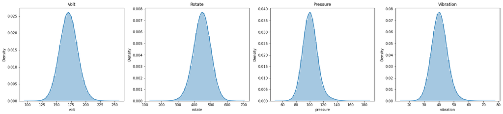

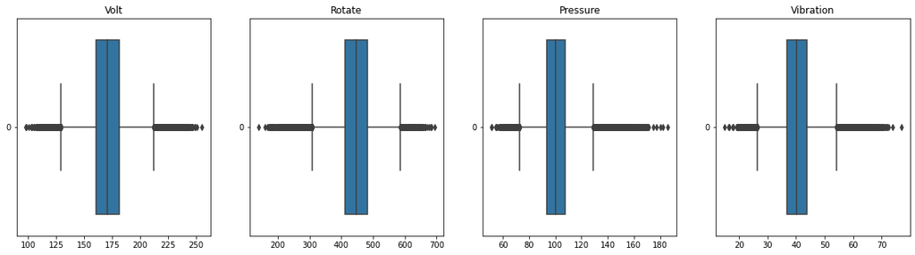

**Objetivo: cruzar as duas bases abaixo com as outras bases do dataset (ex.: telemetria) procurando por um padrão de comportamento das falhas**

**Quantidade de falhas por dia - Out./Nov. 2015**

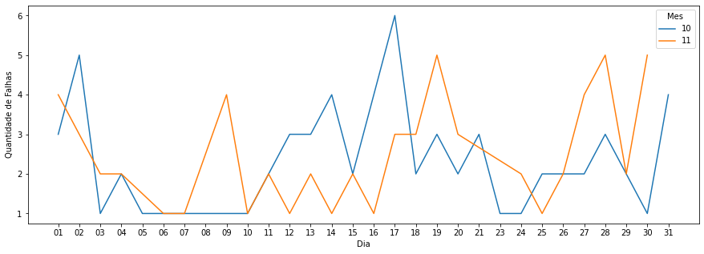

**Quantidade de logs de erro por dia - Out./Nov. 2015**

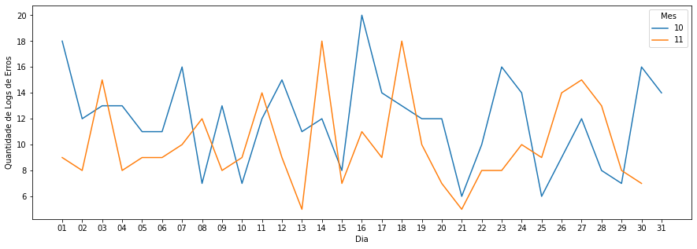

```
[NbConvertApp] Converting notebook Projeto - IoT.ipynb to html
[NbConvertApp] Writing 583285 bytes to notebook_file.html
```